# FDI Data Analysis

Rob Wells

5/4/2020

Import data from Bureau of Economic Analysis Details: Foreign Direct Investment in the U.S.,Foreign Direct Investment Position in the United States on a Historical-Cost Basis  
Bureau of Economic Analysis  
By Country Only (Major Countries) (Millions of Dollars)  
https://apps.bea.gov/iTable/iTable.cfm?reqid=2&step=10&isuri=1&step1prompt1=2&step2prompt3=1&step1prompt2=1&step8prompt10a=2,4,23,35,38,45,85&step4prompt5=4&step3prompt4=22&step5prompt6=1,2&step7prompt8=11,12,13,14,15,16,17,18,19,20,21,22,23,24,25,26,27,28,29,30,31,32,33,34,35,36,37,38,39,40,41,42,43,48,49,52,55,56,58&step8prompt9a=2

```r
FDI2018 <- rio::import("https://github.com/profrobwells/ChinaFDI/blob/master/Data/BEA%20FDI%20Data%20China%20and%20World%202002-2018.xlsx?raw=true", which="China and World", skip=5)
```

```
## * `` -> ...1
## * `` -> ...3
## * `` -> ...4
## * `` -> ...5
## * `` -> ...6
## * … and 34 more problems
```

```r
FDI2018 <- FDI2018[-c(10:24),]
FDI2018 <- janitor::clean_names(FDI2018)
```

```r
FDI2018a <- as.data.frame(t(FDI2018))
FDI2018a <- janitor::clean_names(FDI2018a)
```

```r
FDI2018a <- FDI2018a %>%
  row_to_names(row_number = 1)
```

```r
colnames(FDI2018a)[1:9] <- c("year", "total_fdi", "europe", "latam", "south_centAmerica", "africa", "mideast", "asia_pacific", "china")
```

```r
FDI2018a[1:9] <- lapply(FDI2018a[1:9], as.character)
FDI2018a[2:9] <- lapply(FDI2018a[2:9], as.numeric)
#FDI2018a$year <- as.Date(as.character(FDI2018a$year),format="%Y")
#FDI2018a$year <- lubridate::year(FDI2018a$year)
glimpse(FDI2018a)
```

```
## Observations: 39
## Variables: 9
## $ year              <chr> "1980", "1981", "1982", "1983", "1984", "1985"…
## $ total_fdi         <dbl> 83046, 108714, 124677, 137061, 164583, 184615,…
## $ europe            <dbl> 54688, 72377, 83193, 92936, 108211, 121413, 14…
## $ latam             <dbl> 9678, 11739, 14229, 15035, 16201, 16826, 16763…
## $ south_centAmerica <dbl> 1260, 1426, 2806, 2747, 2859, 3491, 4190, 3935…
## $ africa            <dbl> NA, NA, NA, NA, NA, NA, NA, 521, 441, 505, 505…
## $ mideast           <dbl> 916, 3588, 4401, 4446, 5336, 4954, 4870, 4973,…
## $ asia_pacific      <dbl> NA, NA, NA, NA, NA, NA, NA, 42108, 60992, 7505…
## $ china             <dbl> NA, NA, NA, NA, NA, NA, NA, NA, NA, NA, NA, NA…
```

```r
ChinaUS <- FDI2018a %>%
  select(year, total_fdi, china) %>%
  filter(year > 2001)
glimpse(ChinaUS)
```

```
## Observations: 17
## Variables: 3
## $ year      <chr> "2002", "2003", "2004", "2005", "2006", "2007", "2008"…
## $ total_fdi <dbl> 1327170, 1395159, 1520316, 1634121, 1840463, 1993156, …
## $ china     <dbl> 385, 284, 435, 574, 785, 584, 1105, 1624, 3300, 3598, …
```

#Basic graphic - labels

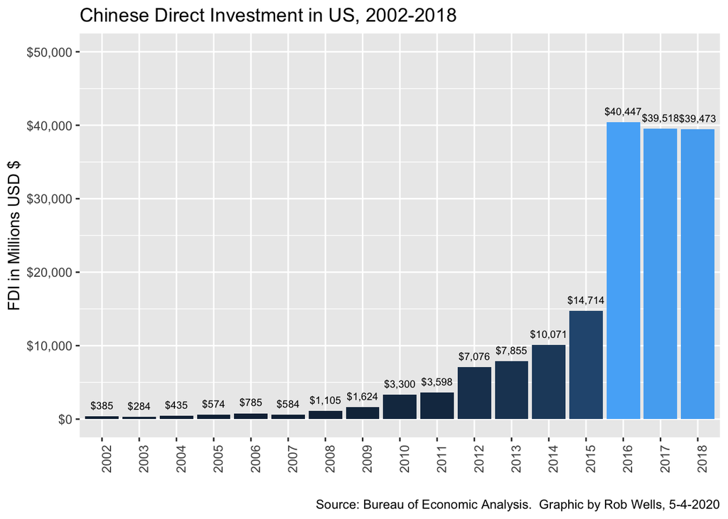

```r
ChinaUS %>%
  ggplot(aes(x = year,
             y = china,
             fill = china)) +
  geom_col(position = "dodge", show.legend = FALSE) +
  theme(axis.text.x = element_text(angle = 90, hjust = 1)) +
  #label formatting. Scales, into percentages. hjust moves to the grid
  # geom_text(aes(label = (china)), position = position_stack(vjust = 5.5), hjust = -5.5, size = 2.5)  +
  #  geom_text(aes(label = scales::comma(china)), size = 2.5, vjust = -1) +
   geom_text(aes(label = scales::dollar(china)), size = 2.5, vjust = -1) +
     scale_y_continuous(limits=c(0, 50000), labels = scales::dollar) +
         labs(title = "Chinese Direct Investment in US, 2002-2018",
       #subtitle = "Districts with More Than 15% Homeless",
       caption = "Source: Bureau of Economic Analysis.  Graphic by Rob Wells, 5-4-2020",
       y="FDI in Millions USD $",
       x="")
```

##Importing Economic Filter Articles for Comparison

```r
EF <- rio::import("https://uark.box.com/shared/static/fp8yu50p7ecul0ayfo9lnowu7ugqkbu7.csv")
```

Frequency Analysis: Table of articles by publication

```r
total <- EF %>%
  group_by(Pub) %>%
  mutate(total_articles = n()) %>%
  ungroup() %>%
  distinct(Pub, total_articles) %>%
  arrange(desc(total_articles)) %>%
  adorn_totals("row")
```

#Makes html table with kables

```r
colnames(total)[1:2] <- c("Publication", "Total Articles")
library(kableExtra)
total %>%
  kable() %>%
  kable_styling("striped")
```

| Publication | Total Articles |
| --- | --- |
| Wall Street Journal | 1768 |
| New York Times | 1197 |
| Inside US Trade | 1048 |
| The Washington Post | 828 |
| Los Angeles Times | 465 |
| Total | 5306 |

Manage Dates

```r
library(lubridate)
EF2 <- EF
EF$datex <- EF$Date
EF <- EF %>%
  mutate(datex = ymd(Date)) %>%
  mutate(yearmon= format(datex, "%Y-%m")) %>%
  mutate(year= format(datex, "%Y"))
```

#Count articles by Year

```r
EconomicFilter_year <- EF %>%
  select(Pub, datex, year) %>%
  group_by(Pub) %>%
  count(year)
```

#Stacked Bar Chart

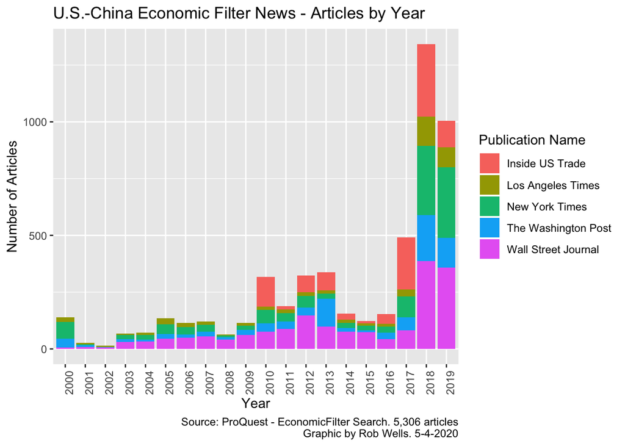

```r
ggplot(EconomicFilter_year, aes(x = year, y = n, fill=Pub))  +
  geom_bar(stat = "identity") +
  theme(axis.text.x = element_text(angle=90)) +
  labs(fill = "Publication Name") +
  labs(title = "U.S.-China Economic Filter News - Articles by Year",
       caption = "Source: ProQuest - EconomicFilter Search. 5,306 articles
       Graphic by Rob Wells. 5-4-2020",
       x="Year",
       y="Number of Articles")
```

```r
#Created EconomicFilter ArticlesYr 2-25-2020
```

#Total articles by Year

```r
total2 <- EF %>%
  select(datex, year) %>%
  count(year)
total2
```

```
## # A tibble: 20 x 2
##    year      n
##    <chr> <int>
##  1 2000    139
##  2 2001     26
##  3 2002     15
##  4 2003     67
##  5 2004     72
##  6 2005    136
##  7 2006    114
##  8 2007    120
##  9 2008     64
## 10 2009    115
## 11 2010    317
## 12 2011    189
## 13 2012    324
## 14 2013    338
## 15 2014    155
## 16 2015    123
## 17 2016    154
## 18 2017    491
## 19 2018   1343
## 20 2019   1004
```

#Join with FDI Data

```r
China_FDI_News <- ChinaUS %>%
  inner_join(total2, by="year")
colnames(China_FDI_News)[3:4] <- c("china_fdi", "total_articles")
China_FDI_News
```

```
##    year total_fdi china_fdi total_articles
## 1  2002   1327170       385             15
## 2  2003   1395159       284             67
## 3  2004   1520316       435             72
## 4  2005   1634121       574            136
## 5  2006   1840463       785            114
## 6  2007   1993156       584            120
## 7  2008   2046662      1105             64
## 8  2009   2069438      1624            115
## 9  2010   2280044      3300            317
## 10 2011   2433848      3598            189
## 11 2012   2584708      7076            324
## 12 2013   2727825      7855            338
## 13 2014   2945795     10071            155
## 14 2015   3354907     14714            123
## 15 2016   3765114     40447            154
## 16 2017   4025492     39518            491
## 17 2018   4344610     39473           1343
```

```r
write.csv(China_FDI_News,"./Data/China_FDI_News.csv")
```

# Correlation between news and FDI inflows

Based on this posting http://www.sthda.com/english/wiki/correlation-test-between-two-variables-in-r

–

### This test shows p-value = 0.004712, which suggests a significant relationship between the number of news articles and the amount of China FDI by year

```r
cor.test(China_FDI_News$china_fdi, China_FDI_News$total_articles, method = "pearson")
```

```
##
##  Pearson's product-moment correlation
##
## data:  China_FDI_News$china_fdi and China_FDI_News$total_articles
## t = 3.3149, df = 15, p-value = 0.004712
## alternative hypothesis: true correlation is not equal to 0
## 95 percent confidence interval:
##  0.2467146 0.8616089
## sample estimates:
##       cor
## 0.6502512
```

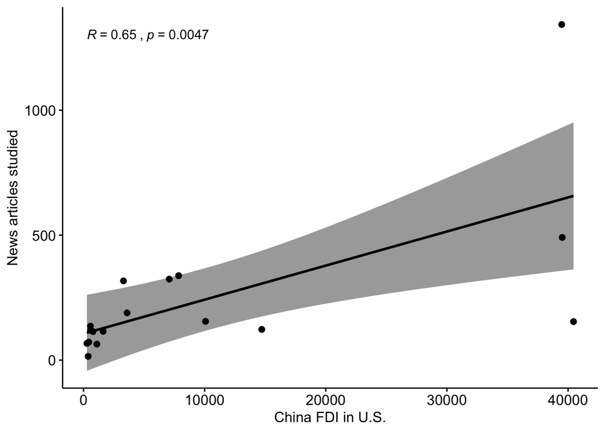

```r
ggscatter(China_FDI_News, x = "china_fdi", y = "total_articles",
          add = "reg.line", conf.int = TRUE,
          cor.coef = TRUE, cor.method = "pearson",
          xlab = "China FDI in U.S.", ylab = "News articles studied")
```

Spearman rank correlation coefficient

Spearman’s rho statistic is also used to estimate a rank-based measure of association. This test may be used if the data do not come from a bivariate normal distribution.

In this case, the correlation coefficient between FDI and news articles is .76, suggesting a strong correlation.

```r
cor.test(China_FDI_News$china_fdi, China_FDI_News$total_articles, method = "spearman")
```

```
##
##  Spearman's rank correlation rho
##
## data:  China_FDI_News$china_fdi and China_FDI_News$total_articles
## S = 196, p-value = 0.0006133
## alternative hypothesis: true rho is not equal to 0
## sample estimates:
##       rho
## 0.7598039
```

http://www.sthda.com/english/wiki/comparing-means-in-r

# Correlate FDI and Sentiment

With Average Bing Sentiment

```r
#Importing from Sentiment analysis 5-8-2020, Line 179
avgbing <- rio::import ("https://raw.githubusercontent.com/profrobwells/ChinaFDI/master/Data/bing_AVG_EF_sent_year.csv")
```

#Join Sentiment with FDI Data

```r
glimpse(ChinaUS)
```

```
## Observations: 17
## Variables: 3
## $ year      <chr> "2002", "2003", "2004", "2005", "2006", "2007", "2008"…
## $ total_fdi <dbl> 1327170, 1395159, 1520316, 1634121, 1840463, 1993156, …
## $ china     <dbl> 385, 284, 435, 574, 785, 584, 1105, 1624, 3300, 3598, …
```

```r
avgbing$year <- as.character(avgbing$year)
glimpse(avgbing)
```

```
## Observations: 40
## Variables: 4
## $ V1         <int> 1, 2, 3, 4, 5, 6, 7, 8, 9, 10, 11, 12, 13, 14, 15, 16…
## $ year       <chr> "2000", "2000", "2001", "2001", "2002", "2002", "2003…
## $ sentiment  <chr> "negative", "positive", "negative", "positive", "nega…
## $ yr_average <dbl> -14.062112, 15.902778, -7.450000, 7.750000, -7.750000…
```

```r
China_FDI_Sent <- ChinaUS %>%
  inner_join(avgbing, by="year")
head(China_FDI_Sent)
```

```
##   year total_fdi china V1 sentiment yr_average
## 1 2002   1327170   385  5  negative   -7.75000
## 2 2002   1327170   385  6  positive    6.37500
## 3 2003   1395159   284  7  negative  -10.37500
## 4 2003   1395159   284  8  positive   10.78689
## 5 2004   1520316   435  9  negative  -12.35632
## 6 2004   1520316   435 10  positive   10.32812
```

```r
China_FDI_Sent$year <- as.numeric(China_FDI_Sent$year)
glimpse(China_FDI_Sent)
```

```
## Observations: 34
## Variables: 6
## $ year       <dbl> 2002, 2002, 2003, 2003, 2004, 2004, 2005, 2005, 2006,…
## $ total_fdi  <dbl> 1327170, 1327170, 1395159, 1395159, 1520316, 1520316,…
## $ china      <dbl> 385, 385, 284, 284, 435, 435, 574, 574, 785, 785, 584…
## $ V1         <int> 5, 6, 7, 8, 9, 10, 11, 12, 13, 14, 15, 16, 17, 18, 19…
## $ sentiment  <chr> "negative", "positive", "negative", "positive", "nega…
## $ yr_average <dbl> -7.750000, 6.375000, -10.375000, 10.786885, -12.35632…
```

```r
#write.csv(China_FDI_Sent,"./Data/China_FDI_Sent.csv")
```

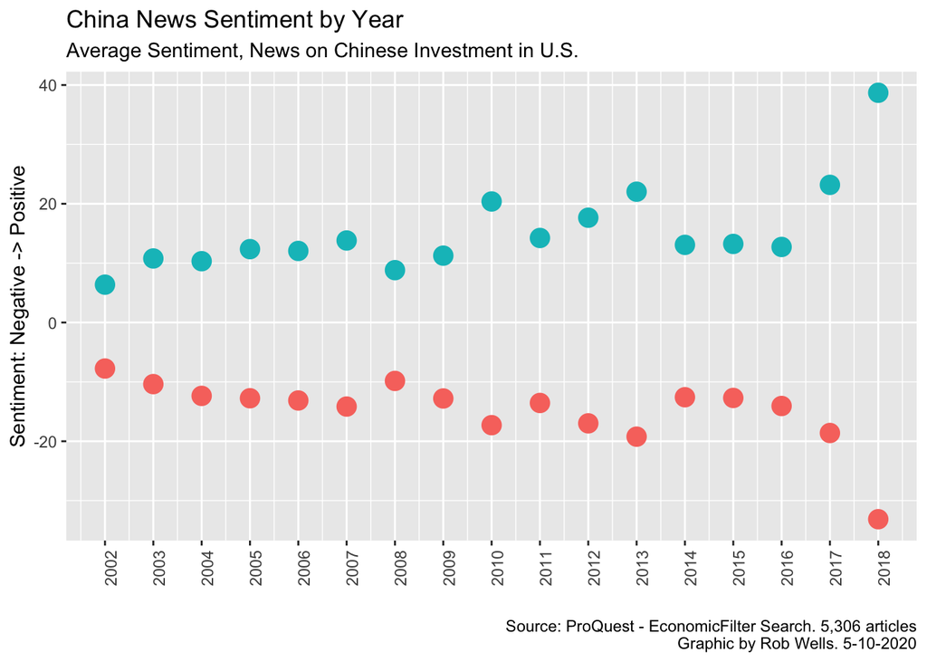

```r
China_FDI_Sent %>%
ggplot(aes(x= year, y= yr_average, color = yr_average > .1, size = 4)) +
  geom_point() +
  scale_x_continuous(breaks=c(2002:2018)) +
  theme(legend.position = "none") +
   theme(axis.text.x = element_text(angle = 90, hjust = 1)) +
   labs(title = "China News Sentiment by Year",
       subtitle = "Average Sentiment, News on Chinese Investment in U.S.",
       caption = "Source: ProQuest - EconomicFilter Search. 5,306 articles
       Graphic by Rob Wells. 5-10-2020",
       x=" ",
       y="Sentiment: Negative -> Positive")
```

```r
#ggsave("AvgChina_Sentiment.png",device = "png",width=10,height=8, dpi=800)
```

# Dual Chart FDI and Sentiment

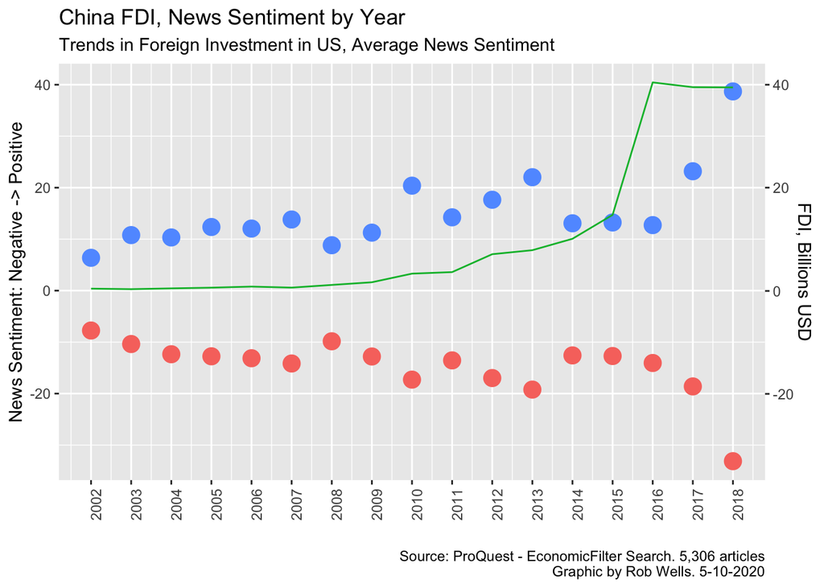

```r
bf <-  ggplot(data= China_FDI_Sent) +
  geom_point(mapping = aes(x= year, y= yr_average,  color = yr_average > .1, size = 4), stat="identity") +
  geom_line(mapping = aes(x= year, y= china/1000, color= "GnBu"), stat="identity") +
  theme(legend.position = "none") +
  scale_y_continuous(name = "News Sentiment: Negative -> Positive",
                     sec.axis = sec_axis(~.*1, name = "FDI, Billions USD")) +
  scale_x_continuous(breaks=c(2002:2018)) +
  theme(axis.text.x = element_text(angle = 90, hjust = 1)) +
   labs(title = "China FDI, News Sentiment by Year",
       subtitle = "Trends in Foreign Investment in US, Average News Sentiment",
       caption = "Source: ProQuest - EconomicFilter Search. 5,306 articles
       Graphic by Rob Wells. 5-10-2020",
       x=" ",
       y="Sentiment: Negative -> Positive")

bf
```

```r
#Created Avg Sentiment FDI 5-11-2020
#ggsave("AvgFDI_Sentiment.png",device = "png",width=10,height=8, dpi=800)
```

## # Correlation between average sentiment and FDI inflows

```r
glimpse(China_FDI_Sent)
```

```
## Observations: 34
## Variables: 6
## $ year       <dbl> 2002, 2002, 2003, 2003, 2004, 2004, 2005, 2005, 2006,…
## $ total_fdi  <dbl> 1327170, 1327170, 1395159, 1395159, 1520316, 1520316,…
## $ china      <dbl> 385, 385, 284, 284, 435, 435, 574, 574, 785, 785, 584…
## $ V1         <int> 5, 6, 7, 8, 9, 10, 11, 12, 13, 14, 15, 16, 17, 18, 19…
## $ sentiment  <chr> "negative", "positive", "negative", "positive", "nega…
## $ yr_average <dbl> -7.750000, 6.375000, -10.375000, 10.786885, -12.35632…
```

### This test shows p-value = 0.006938, which suggests a significant relationship between average negative sentiment in news articles and the amount of China FDI by year

```r
neg <- China_FDI_Sent %>%
  filter(sentiment=="negative")

cor.test(neg$china, neg$yr_average, method = "pearson")
```

```
##
##  Pearson's product-moment correlation
##
## data:  neg$china and neg$yr_average
## t = -3.1261, df = 15, p-value = 0.006938
## alternative hypothesis: true correlation is not equal to 0
## 95 percent confidence interval:
##  -0.8516320 -0.2111921
## sample estimates:
##        cor
## -0.6280814
```

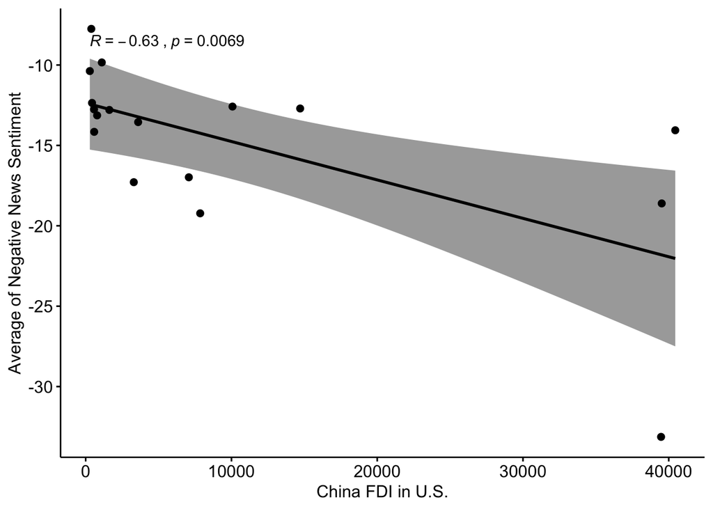

```r
ggscatter(neg, x = "china", y = "yr_average",
          add = "reg.line", conf.int = TRUE,
          cor.coef = TRUE, cor.method = "pearson",
          xlab = "China FDI in U.S.", ylab = "Average of Negative News Sentiment")
```

### This test shows p-value = 0.006321, which suggests a significant relationship between average positive sentiment in news articles and the amount of China FDI by year

```r
pos <- China_FDI_Sent %>%
  filter(sentiment=="positive")

cor.test(pos$china, pos$yr_average, method = "pearson")
```

```
##
##  Pearson's product-moment correlation
##
## data:  pos$china and pos$yr_average
## t = 3.1716, df = 15, p-value = 0.006321
## alternative hypothesis: true correlation is not equal to 0
## 95 percent confidence interval:
##  0.2198850 0.8541172
## sample estimates:
##       cor
## 0.6335699
```

# This chart examines the trends in FDI and positive news sentiment

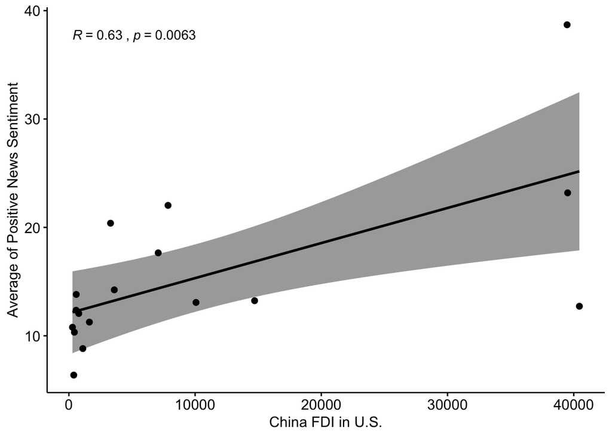

```r
ggscatter(pos, x = "china", y = "yr_average",
          add = "reg.line", conf.int = TRUE,
          cor.coef = TRUE, cor.method = "pearson",
          xlab = "China FDI in U.S.", ylab = "Average of Positive News Sentiment")
```

## Analyzing Total Bing Sentiment

### This is an alternate examination of total – not average – sentiment. This is distorted by the number of articles – more articles equals more words equals a higher or lower sentiment score. But I present the aggregates just the same.

```r
#Importing from Sentiment analysis 5-8-2020, Line 135
Bing <- rio::import("https://raw.githubusercontent.com/profrobwells/ChinaFDI/master/Data/EF_bing_year_total.csv")
```

#Join Sentiment with FDI Data

```r
glimpse(ChinaUS)
```

```
## Observations: 17
## Variables: 3
## $ year      <chr> "2002", "2003", "2004", "2005", "2006", "2007", "2008"…
## $ total_fdi <dbl> 1327170, 1395159, 1520316, 1634121, 1840463, 1993156, …
## $ china     <dbl> 385, 284, 435, 574, 785, 584, 1105, 1624, 3300, 3598, …
```

```r
Bing$year <- as.character(Bing$year)
glimpse(Bing)
```

```
## Observations: 40
## Variables: 4
## $ V1        <int> 1, 2, 3, 4, 5, 6, 7, 8, 9, 10, 11, 12, 13, 14, 15, 16,…
## $ year      <chr> "2000", "2000", "2001", "2001", "2002", "2002", "2003"…
## $ sentiment <chr> "negative", "positive", "negative", "positive", "negat…
## $ yrtotal   <int> -2264, 2290, -149, 124, -62, 51, -913, 658, -1075, 661…
```

```r
China_FDI_Total_Sent <- ChinaUS %>%
  inner_join(Bing, by="year")
head(China_FDI_Total_Sent)
```

```
##   year total_fdi china V1 sentiment yrtotal
## 1 2002   1327170   385  5  negative     -62
## 2 2002   1327170   385  6  positive      51
## 3 2003   1395159   284  7  negative    -913
## 4 2003   1395159   284  8  positive     658
## 5 2004   1520316   435  9  negative   -1075
## 6 2004   1520316   435 10  positive     661
```

```r
China_FDI_Total_Sent$year <- as.numeric(China_FDI_Total_Sent$year)
glimpse(China_FDI_Total_Sent)
```

```
## Observations: 34
## Variables: 6
## $ year      <dbl> 2002, 2002, 2003, 2003, 2004, 2004, 2005, 2005, 2006, …
## $ total_fdi <dbl> 1327170, 1327170, 1395159, 1395159, 1520316, 1520316, …
## $ china     <dbl> 385, 385, 284, 284, 435, 435, 574, 574, 785, 785, 584,…
## $ V1        <int> 5, 6, 7, 8, 9, 10, 11, 12, 13, 14, 15, 16, 17, 18, 19,…
## $ sentiment <chr> "negative", "positive", "negative", "positive", "negat…
## $ yrtotal   <int> -62, 51, -913, 658, -1075, 661, -2105, 1545, -1484, 12…
```

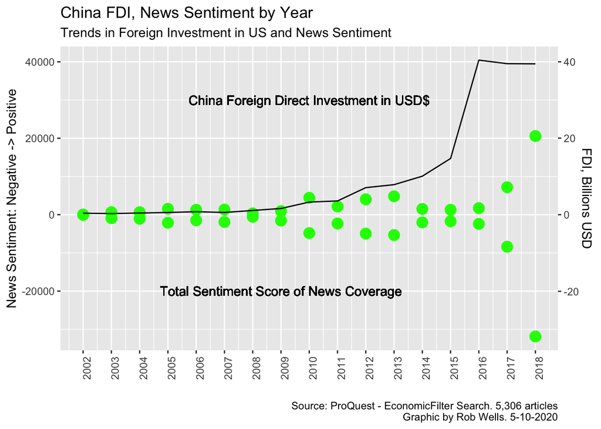

```r
zz <-  ggplot(data= China_FDI_Total_Sent) +
  geom_point(aes(x= year, y= yrtotal), size = 4, color = "green", fill = "green", stat="identity") +
  geom_line(mapping = aes(x= year, y= china, fill= "blue"), stat="identity") +
  scale_y_continuous(name = "News Sentiment: Negative -> Positive",
                     sec.axis = sec_axis(~.*.001, name = "FDI, Billions USD")) +
 scale_x_continuous(breaks=c(2002:2018)) +
   theme(axis.text.x = element_text(angle = 90, hjust = 1)) +
  geom_text(label= "China Foreign Direct Investment in USD$",
            x= 2010, y= 30000) +
    geom_text(label= "Total Sentiment Score of News Coverage",
            x= 2009, y= -20000) +
  labs(title = "China FDI, News Sentiment by Year",
       subtitle = "Trends in Foreign Investment in US and News Sentiment",
       caption = "Source: ProQuest - EconomicFilter Search. 5,306 articles
       Graphic by Rob Wells. 5-10-2020",
       x=" ",
       y="Sentiment: Negative -> Positive")
zz
```

```r
#Created FDI Sentiment 5-10-2020
#ggsave("ChinaFDI_Sentiment.png",device = "png",width=10,height=8, dpi=800)
```

### This test shows p-value = 0.006892, which suggests a significant relationship between total negative sentiment in news articles and the amount of China FDI by year

```r
neg1 <- China_FDI_Total_Sent %>%
  filter(sentiment=="negative")

cor.test(neg1$china, neg1$yrtotal, method = "pearson")
```

```
##
##  Pearson's product-moment correlation
##
## data:  neg1$china and neg1$yrtotal
## t = -3.1293, df = 15, p-value = 0.006892
## alternative hypothesis: true correlation is not equal to 0
## 95 percent confidence interval:
##  -0.8518115 -0.2118167
## sample estimates:
##        cor
## -0.6284771
```

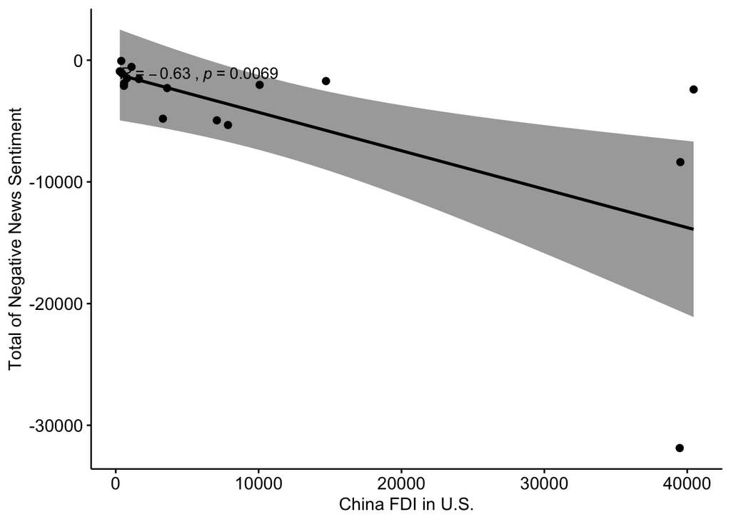

```r
ggscatter(neg1, x = "china", y = "yrtotal",
          add = "reg.line", conf.int = TRUE,
          cor.coef = TRUE, cor.method = "pearson",
          xlab = "China FDI in U.S.", ylab = "Total of Negative News Sentiment")
```

### This test shows p-value = 0.004983, which suggests a significant relationship between total positive sentiment in news articles and the amount of China FDI by year

```r
pos1 <- China_FDI_Total_Sent %>%
  filter(sentiment=="positive")

cor.test(pos1$china, pos1$yrtotal, method = "pearson")
```

```
##
##  Pearson's product-moment correlation
##
## data:  pos1$china and pos1$yrtotal
## t = 3.2877, df = 15, p-value = 0.004983
## alternative hypothesis: true correlation is not equal to 0
## 95 percent confidence interval:
##  0.2416828 0.8602240
## sample estimates:
##       cor
## 0.6471521
```

# This chart examines the trends in FDI and positive news sentiment

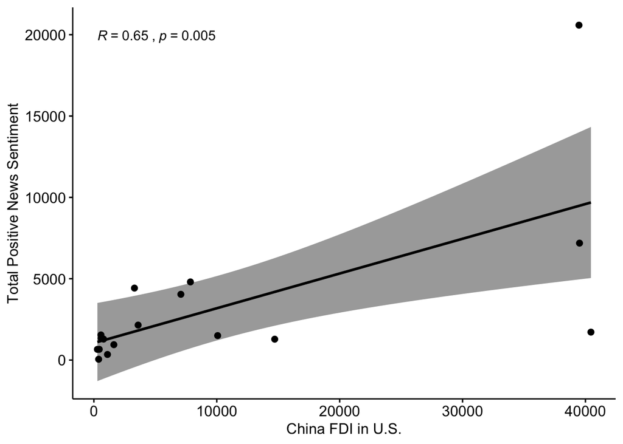

```r
ggscatter(pos1, x = "china", y = "yrtotal",
          add = "reg.line", conf.int = TRUE,
          cor.coef = TRUE, cor.method = "pearson",
          xlab = "China FDI in U.S.", ylab = "Total Positive News Sentiment")
```